# Random Forest Modelling for Predicting Rain in Australia

Using Tidymodels package in R

FRK

July 21, 2021

# 1 Loading packages

We are going to use **Tidymodels** package, the latest developed package by Rstudio for modeling and machine learning methods.

```r
rm(list = ls())

library(tidyverse)
library(tidymodels)
library(lubridate)
library(skimr)
library(ggplot2)
```

# 2 Exploring Data

## 2.1 Reading and Glimpse of the Data

```r
#rm(list=ls())
aus <- read_csv("weatherAUS.csv", na = "NA", col_types = cols(
  Evaporation = col_double(),
  Sunshine = col_double()
))

#### Summary of the data

glimpse(aus)
```

```
## Rows: 145,460
## Columns: 23
## $ Date          <date> 2008-12-01, 2008-12-02, 2008-12-03, 2008-12-04, 2008...
## $ Location      <chr> "Albury", "Albury", "Albury", "Albury", "Albury", "Al...
## $ MinTemp       <dbl> 13.4, 7.4, 12.9, 9.2, 17.5, 14.6, 14.3, 7.7, 9.7, 13....
## $ MaxTemp       <dbl> 22.9, 25.1, 25.7, 28.0, 32.3, 29.7, 25.0, 26.7, 31.9,...
## $ Rainfall      <dbl> 0.6, 0.0, 0.0, 0.0, 1.0, 0.2, 0.0, 0.0, 0.0, 1.4, 0.0...
## $ Evaporation   <dbl> NA, NA, NA, NA, NA, NA, NA, NA, NA, NA, NA, NA, NA, N...
## $ Sunshine      <dbl> NA, NA, NA, NA, NA, NA, NA, NA, NA, NA, NA, NA, NA, N...
## $ WindGustDir   <chr> "W", "WNW", "WSW", "NE", "W", "WNW", "W", "W", "NNW",...
## $ WindGustSpeed <dbl> 44, 44, 46, 24, 41, 56, 50, 35, 80, 28, 30, 31, 61, 4...
## $ WindDir9am    <chr> "W", "NNW", "W", "SE", "ENE", "W", "SW", "SSE", "SE",...
## $ WindDir3pm    <chr> "WNW", "WSW", "WSW", "E", "NW", "W", "W", "W", "NW", ...
## $ WindSpeed9am  <dbl> 20, 4, 19, 11, 7, 19, 20, 6, 7, 15, 17, 15, 28, 24, 4...
## $ WindSpeed3pm  <dbl> 24, 22, 26, 9, 20, 24, 24, 17, 28, 11, 6, 13, 28, 20,...
## $ Humidity9am   <dbl> 71, 44, 38, 45, 82, 55, 49, 48, 42, 58, 48, 89, 76, 6...
## $ Humidity3pm   <dbl> 22, 25, 30, 16, 33, 23, 19, 19, 9, 27, 22, 91, 93, 43...
## $ Pressure9am   <dbl> 1007.7, 1010.6, 1007.6, 1017.6, 1010.8, 1009.2, 1009....
## $ Pressure3pm   <dbl> 1007.1, 1007.8, 1008.7, 1012.8, 1006.0, 1005.4, 1008....
## $ Cloud9am      <dbl> 8, NA, NA, NA, 7, NA, 1, NA, NA, NA, NA, 8, 8, NA, NA...
## $ Cloud3pm      <dbl> NA, NA, 2, NA, 8, NA, NA, NA, NA, NA, NA, 8, 8, 7, NA...
## $ Temp9am       <dbl> 16.9, 17.2, 21.0, 18.1, 17.8, 20.6, 18.1, 16.3, 18.3,...
## $ Temp3pm       <dbl> 21.8, 24.3, 23.2, 26.5, 29.7, 28.9, 24.6, 25.5, 30.2,...
## $ RainToday     <chr> "No", "No", "No", "No", "No", "No", "No", "No", "No",...
## $ RainTomorrow  <chr> "No", "No", "No", "No", "No", "No", "No", "No", "Yes"...
```

```r
summary(aus)
```

```
##       Date              Location            MinTemp         MaxTemp
##  Min.   :2007-11-01   Length:145460      Min.   :-8.50   Min.   :-4.80
##  1st Qu.:2011-01-11   Class :character   1st Qu.: 7.60   1st Qu.:17.90
##  Median :2013-06-02   Mode  :character   Median :12.00   Median :22.60
##  Mean   :2013-04-04                      Mean   :12.19   Mean   :23.22
##  3rd Qu.:2015-06-14                      3rd Qu.:16.90   3rd Qu.:28.20
##  Max.   :2017-06-25                      Max.   :33.90   Max.   :48.10
##                                          NA's   :1485    NA's   :1261
##     Rainfall        Evaporation        Sunshine     WindGustDir
##  Min.   :  0.000   Min.   :  0.00   Min.   : 0.00   Length:145460
##  1st Qu.:  0.000   1st Qu.:  2.60   1st Qu.: 4.80   Class :character
##  Median :  0.000   Median :  4.80   Median : 8.40   Mode  :character
##  Mean   :  2.361   Mean   :  5.47   Mean   : 7.61
##  3rd Qu.:  0.800   3rd Qu.:  7.40   3rd Qu.:10.60
##  Max.   :371.000   Max.   :145.00   Max.   :14.50
##  NA's   :3261      NA's   :62790    NA's   :69835
##  WindGustSpeed     WindDir9am         WindDir3pm         WindSpeed9am
##  Min.   :  6.00   Length:145460      Length:145460      Min.   :  0.00
##  1st Qu.: 31.00   Class :character   Class :character   1st Qu.:  7.00
##  Median : 39.00   Mode  :character   Mode  :character   Median : 13.00
##  Mean   : 40.03                                         Mean   : 14.04
##  3rd Qu.: 48.00                                         3rd Qu.: 19.00
##  Max.   :135.00                                         Max.   :130.00
##  NA's   :10263                                          NA's   :1767
##   WindSpeed3pm    Humidity9am      Humidity3pm      Pressure9am
##  Min.   : 0.00   Min.   :  0.00   Min.   :  0.00   Min.   : 980.5
##  1st Qu.:13.00   1st Qu.: 57.00   1st Qu.: 37.00   1st Qu.:1012.9
##  Median :19.00   Median : 70.00   Median : 52.00   Median :1017.6
##  Mean   :18.66   Mean   : 68.88   Mean   : 51.54   Mean   :1017.6
##  3rd Qu.:24.00   3rd Qu.: 83.00   3rd Qu.: 66.00   3rd Qu.:1022.4
##  Max.   :87.00   Max.   :100.00   Max.   :100.00   Max.   :1041.0
##  NA's   :3062    NA's   :2654     NA's   :4507     NA's   :15065
##   Pressure3pm        Cloud9am        Cloud3pm        Temp9am
##  Min.   : 977.1   Min.   :0.00    Min.   :0.00    Min.   :-7.20
##  1st Qu.:1010.4   1st Qu.:1.00    1st Qu.:2.00    1st Qu.:12.30
##  Median :1015.2   Median :5.00    Median :5.00    Median :16.70
##  Mean   :1015.3   Mean   :4.45    Mean   :4.51    Mean   :16.99
##  3rd Qu.:1020.0   3rd Qu.:7.00    3rd Qu.:7.00    3rd Qu.:21.60
##  Max.   :1039.6   Max.   :9.00    Max.   :9.00    Max.   :40.20
##  NA's   :15028    NA's   :55888   NA's   :59358   NA's   :1767
##     Temp3pm       RainToday         RainTomorrow
##  Min.   :-5.40   Length:145460      Length:145460
##  1st Qu.:16.60   Class :character   Class :character
##  Median :21.10   Mode  :character   Mode  :character
##  Mean   :21.68
##  3rd Qu.:26.40
##  Max.   :46.70
##  NA's   :3609
```

```r
skim(aus)
```

Data summary

| Name | aus |
| --- | --- |
| Number of rows | 145460 |
| Number of columns | 23 |
| _______________________ |  |
| Column type frequency: |  |
| character | 6 |
| Date | 1 |
| numeric | 16 |
| ________________________ |  |
| Group variables | None |

**Variable type: character**

| skim_variable | n_missing | complete_rate | min | max | empty | n_unique | whitespace |
| --- | --- | --- | --- | --- | --- | --- | --- |
| Location | 0 | 1.00 | 4 | 16 | 0 | 49 | 0 |
| WindGustDir | 10326 | 0.93 | 1 | 3 | 0 | 16 | 0 |
| WindDir9am | 10566 | 0.93 | 1 | 3 | 0 | 16 | 0 |
| WindDir3pm | 4228 | 0.97 | 1 | 3 | 0 | 16 | 0 |
| RainToday | 3261 | 0.98 | 2 | 3 | 0 | 2 | 0 |
| RainTomorrow | 3267 | 0.98 | 2 | 3 | 0 | 2 | 0 |

**Variable type: Date**

| skim_variable | n_missing | complete_rate | min | max | median | n_unique |
| --- | --- | --- | --- | --- | --- | --- |
| Date | 0 | 1 | 2007-11-01 | 2017-06-25 | 2013-06-02 | 3436 |

**Variable type: numeric**

| skim_variable | n_missing | complete_rate | mean | sd | p0 | p25 | p50 | p75 | p100 | hist |
| --- | --- | --- | --- | --- | --- | --- | --- | --- | --- | --- |
| MinTemp | 1485 | 0.99 | 12.19 | 6.40 | -8.5 | 7.6 | 12.0 | 16.9 | 33.9 | ▁▅▇▅▁ |
| MaxTemp | 1261 | 0.99 | 23.22 | 7.12 | -4.8 | 17.9 | 22.6 | 28.2 | 48.1 | ▁▂▇▅▁ |
| Rainfall | 3261 | 0.98 | 2.36 | 8.48 | 0.0 | 0.0 | 0.0 | 0.8 | 371.0 | ▇▁▁▁▁ |
| Evaporation | 62790 | 0.57 | 5.47 | 4.19 | 0.0 | 2.6 | 4.8 | 7.4 | 145.0 | ▇▁▁▁▁ |
| Sunshine | 69835 | 0.52 | 7.61 | 3.79 | 0.0 | 4.8 | 8.4 | 10.6 | 14.5 | ▃▃▅▇▃ |
| WindGustSpeed | 10263 | 0.93 | 40.04 | 13.61 | 6.0 | 31.0 | 39.0 | 48.0 | 135.0 | ▅▇▁▁▁ |
| WindSpeed9am | 1767 | 0.99 | 14.04 | 8.92 | 0.0 | 7.0 | 13.0 | 19.0 | 130.0 | ▇▁▁▁▁ |
| WindSpeed3pm | 3062 | 0.98 | 18.66 | 8.81 | 0.0 | 13.0 | 19.0 | 24.0 | 87.0 | ▇▇▁▁▁ |
| Humidity9am | 2654 | 0.98 | 68.88 | 19.03 | 0.0 | 57.0 | 70.0 | 83.0 | 100.0 | ▁▁▅▇▆ |
| Humidity3pm | 4507 | 0.97 | 51.54 | 20.80 | 0.0 | 37.0 | 52.0 | 66.0 | 100.0 | ▂▅▇▆▂ |
| Pressure9am | 15065 | 0.90 | 1017.65 | 7.11 | 980.5 | 1012.9 | 1017.6 | 1022.4 | 1041.0 | ▁▁▇▇▁ |
| Pressure3pm | 15028 | 0.90 | 1015.26 | 7.04 | 977.1 | 1010.4 | 1015.2 | 1020.0 | 1039.6 | ▁▁▇▇▁ |
| Cloud9am | 55888 | 0.62 | 4.45 | 2.89 | 0.0 | 1.0 | 5.0 | 7.0 | 9.0 | ▇▃▃▇▅ |
| Cloud3pm | 59358 | 0.59 | 4.51 | 2.72 | 0.0 | 2.0 | 5.0 | 7.0 | 9.0 | ▆▅▃▇▃ |
| Temp9am | 1767 | 0.99 | 16.99 | 6.49 | -7.2 | 12.3 | 16.7 | 21.6 | 40.2 | ▁▃▇▃▁ |
| Temp3pm | 3609 | 0.98 | 21.68 | 6.94 | -5.4 | 16.6 | 21.1 | 26.4 | 46.7 | ▁▃▇▃▁ |

The data is from various weather related data from many locations of Australia.

We are going to predict the variable **RainTomorrow**. So we want to predict if it is going to rain tomorrow or not based on today’s data.

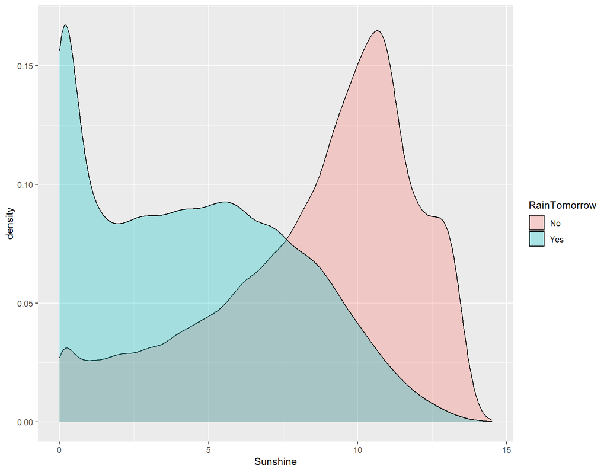

```r
### SUnshine looks important, but there are 70,000 missing values

aus %>%
  select(Sunshine, RainTomorrow) %>%
  drop_na() %>%
  ggplot(aes(Sunshine, fill = RainTomorrow)) +
  geom_density( alpha = 0.3)
```

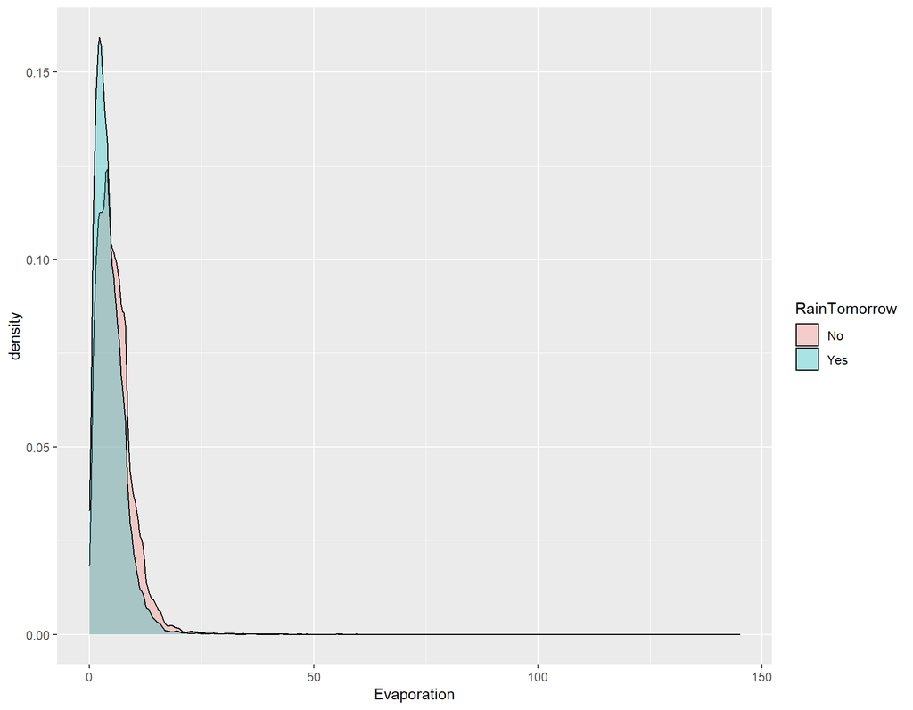

```r
### Evaporation does not seem important, as there is significant overlap

aus %>%
  select(Evaporation, RainTomorrow) %>%
  drop_na() %>%
  ggplot(aes(Evaporation, fill = RainTomorrow)) +
  geom_density( alpha = 0.3)
```

## 2.2 Drop Sunshine and Evaporation

As these two variables have too many missing values.

```r
aus <- aus %>% select(-Sunshine, -Evaporation)
```

## 2.3 Location wise Exploring the Data

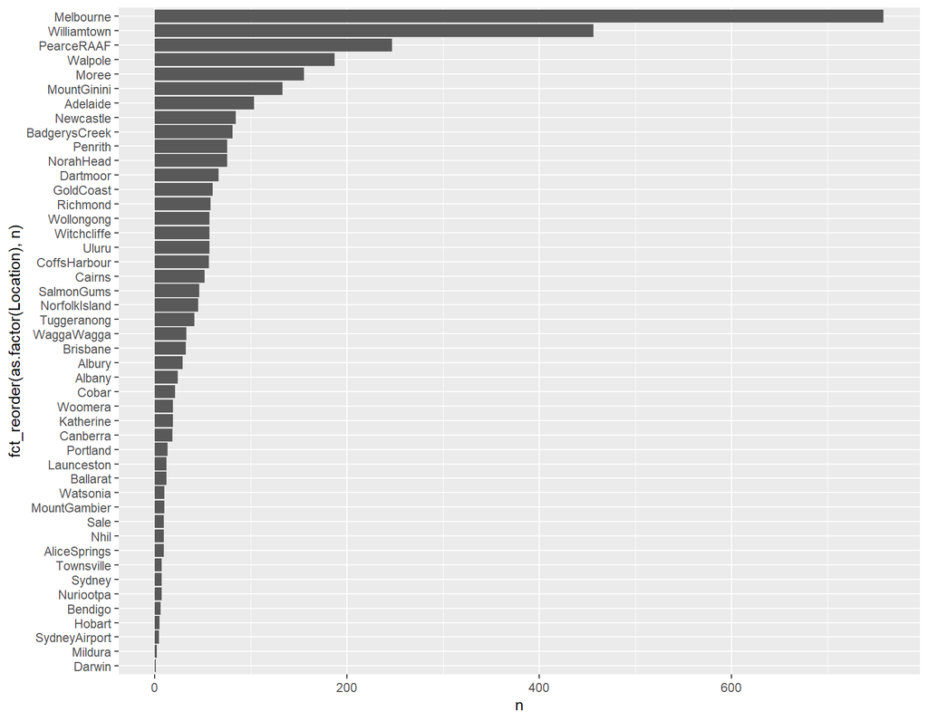

```r
### Missing RainTomorrow by Location

aus %>%
  select(Location, RainTomorrow) %>%
  count(Location, RainTomorrow) %>%
  arrange(n, Location) %>%
  filter(is.na(RainTomorrow)) %>%
  mutate(total = sum(n)) %>%
  ggplot(aes(n , fct_reorder(as.factor(Location), n))) +
  geom_col(position = "dodge")
```

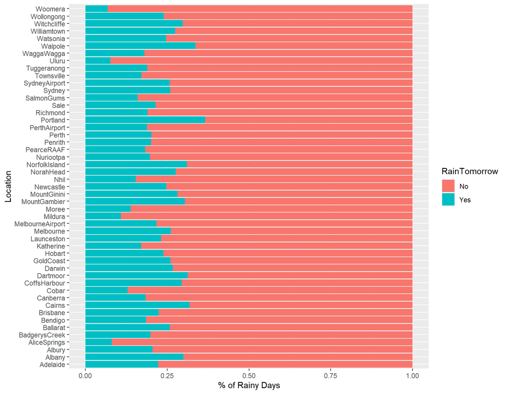

```r
### Location wise Rain Percentage

aus %>%
  select(Location, RainTomorrow) %>%
  count(Location, RainTomorrow) %>%
  drop_na() %>%
  group_by(Location) %>%
  mutate(percent_Rain = n / sum(n)) %>%
  ggplot(aes(percent_Rain , Location, fill = RainTomorrow)) +
  geom_col() +
  ylab("Location") +
  xlab("% of Rainy Days")
```

There are some locations with more rain than others.

## 2.4 Exploring Monthly Rain

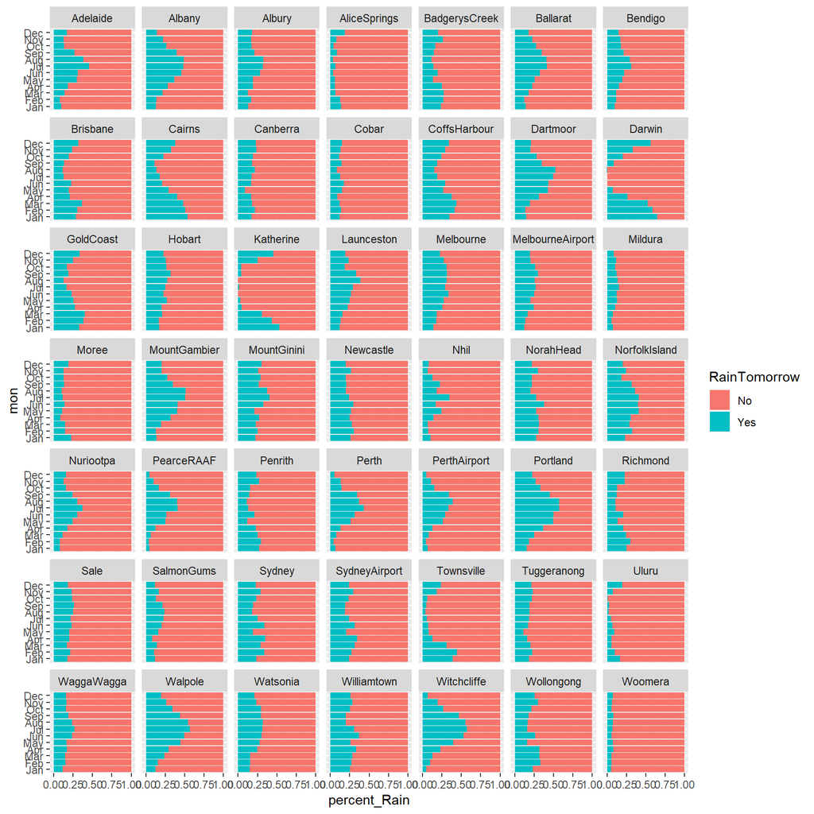

```r
aus %>%
  mutate(mon = lubridate::month(aus$Date, label = TRUE)) %>%
  count(Location, mon, RainTomorrow) %>%
  drop_na() %>%
  group_by(Location, mon) %>%
  mutate(percent_Rain = n / sum(n)) %>%
  ggplot(aes(percent_Rain , mon, fill = RainTomorrow)) +
  geom_col() +
  facet_wrap(~Location)
```

Month seems to be a very important factor, when separated by Location

## 2.5 Temperature and RainTomorrow

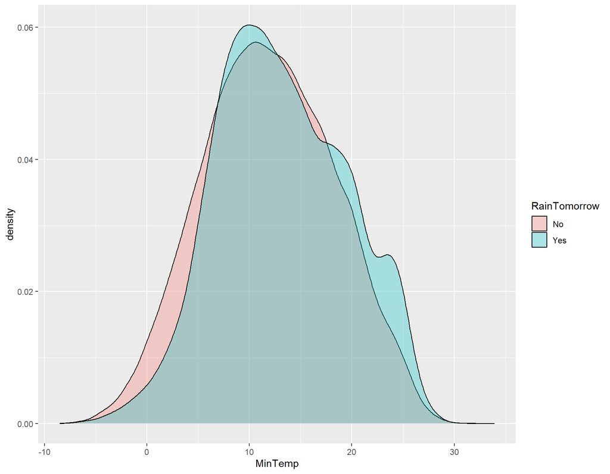

```r
aus %>%
  select(MinTemp, RainTomorrow) %>%
  drop_na() %>%
  ggplot(aes(MinTemp, fill = RainTomorrow)) +
  geom_density( alpha = 0.3)
```

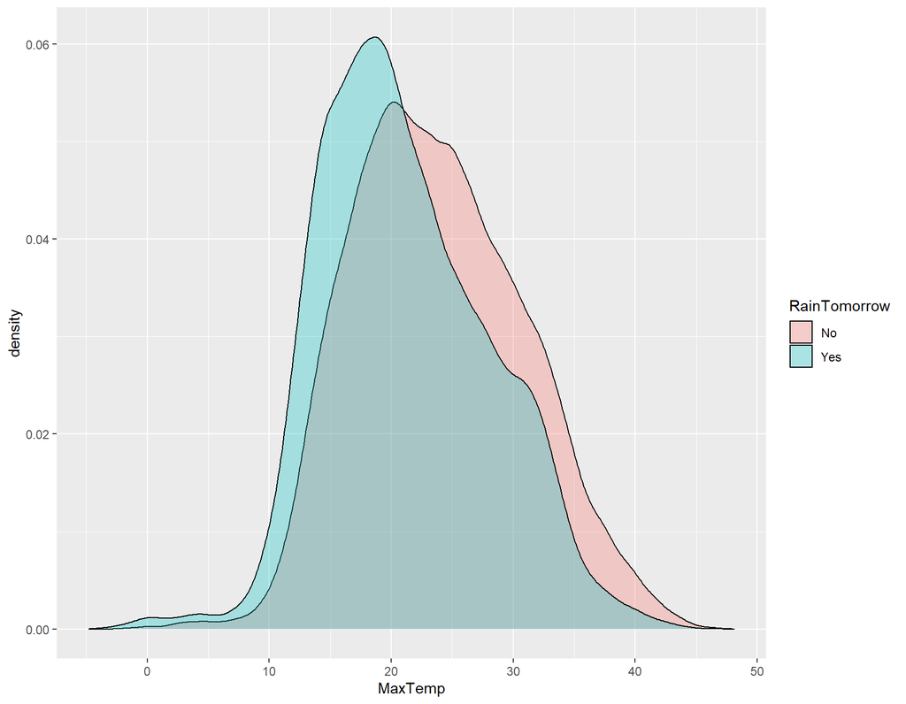

```r
aus %>%
  select(MaxTemp, RainTomorrow) %>%
  drop_na() %>%
  ggplot(aes(MaxTemp, fill = RainTomorrow)) +
  geom_density( alpha = 0.3)
```

Mintemp & Maxtemp doesnt seem too important, by could be useful location wise.

## 2.6 With Rainfall today

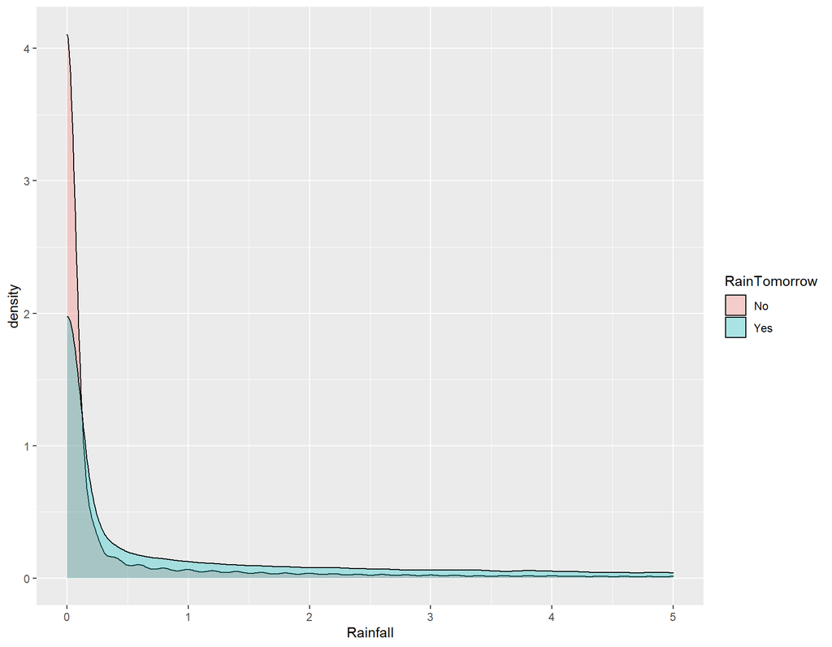

```r
aus %>%
  select(Rainfall, RainTomorrow) %>%
  drop_na() %>%
  ggplot(aes(Rainfall, fill = RainTomorrow)) +
  geom_density( alpha = 0.3) +
  xlim(0, 5)
```

```r
aus %>%
  count(RainToday, RainTomorrow) %>%
  drop_na()
```

```
## # A tibble: 4 x 3
##   RainToday RainTomorrow     n
##   <chr>     <chr>        <int>
## 1 No        No           92728
## 2 No        Yes          16604
## 3 Yes       No           16858
## 4 Yes       Yes          14597
```

```r
chisq.test(table(aus$RainToday, aus$RainTomorrow))
```

```
##
##  Pearson's Chi-squared test with Yates' continuity correction
##
## data:  table(aus$RainToday, aus$RainTomorrow)
## X-squared = 13799, df = 1, p-value < 2.2e-16
```

Raifall seems important, observing the long tail of Yes category, and chisquare test is significant

## 2.7 Windgust and Direction

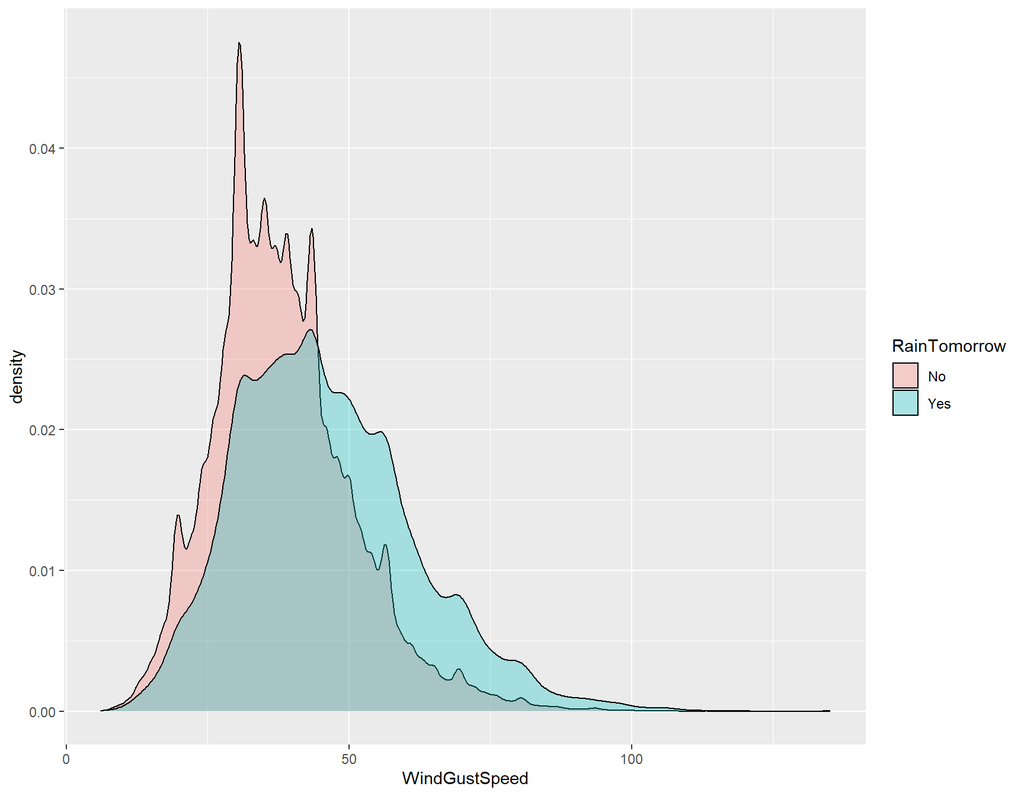

```r
aus %>%
  select(WindGustSpeed, RainTomorrow) %>%
  drop_na() %>%
  ggplot(aes(WindGustSpeed, fill = RainTomorrow)) +
  geom_density(alpha = 0.3)
```

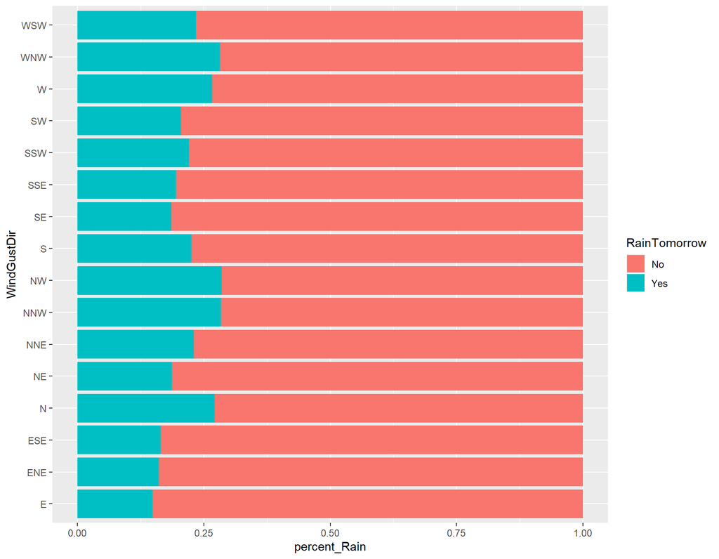

```r
aus %>%
  select(WindGustDir, RainTomorrow) %>%
  count(WindGustDir, RainTomorrow) %>%
  drop_na() %>%
  group_by(WindGustDir) %>%
  mutate(percent_Rain = n / sum(n)) %>%
  ggplot(aes(percent_Rain , WindGustDir, fill = RainTomorrow)) +
  geom_col()
```

WindGustSpeed & WindGustDir is important

## 2.8 Wind Direction and RainTomorrow

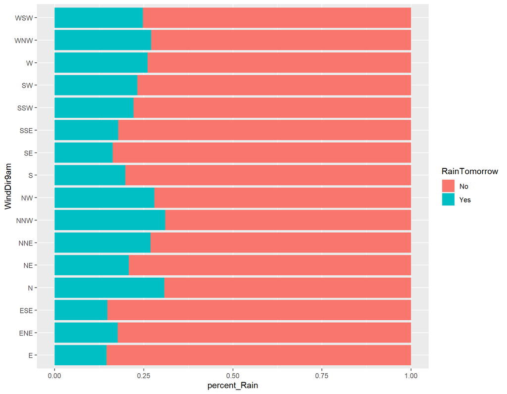

```r
aus %>%
  select(WindDir9am, RainTomorrow) %>%
  count(WindDir9am, RainTomorrow) %>%
  drop_na() %>%
  group_by(WindDir9am) %>%
  mutate(percent_Rain = n / sum(n)) %>%
  ggplot(aes(percent_Rain , WindDir9am, fill = RainTomorrow)) +
  geom_col()
```

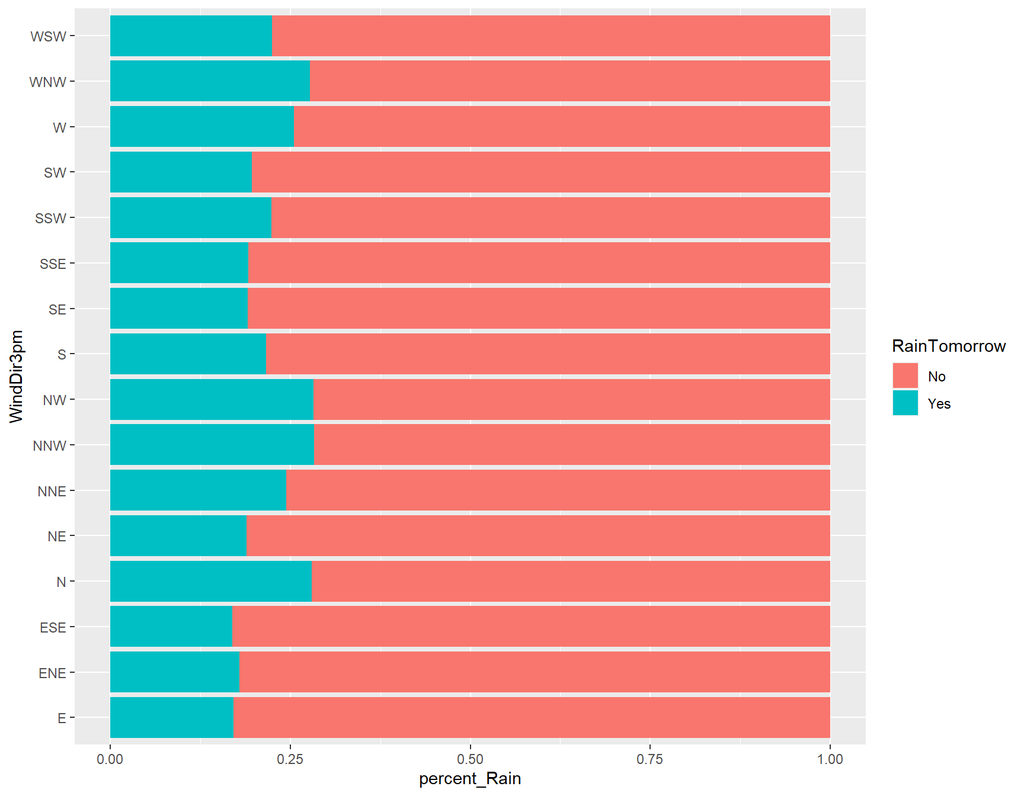

```r
aus %>%
  select(WindDir3pm, RainTomorrow) %>%
  count(WindDir3pm, RainTomorrow) %>%
  drop_na() %>%
  group_by(WindDir3pm) %>%
  mutate(percent_Rain = n / sum(n)) %>%
  ggplot(aes(percent_Rain , WindDir3pm, fill = RainTomorrow)) +
  geom_col()
```

Wind Direction is also important

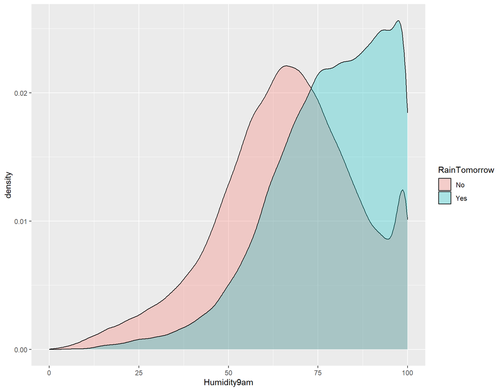

```r
### Humidity seems to have a big effect

aus %>%
  select(Humidity9am, RainTomorrow) %>%
  drop_na() %>%
  ggplot(aes(Humidity9am, fill = RainTomorrow)) +
  geom_density(alpha = 0.3)
```

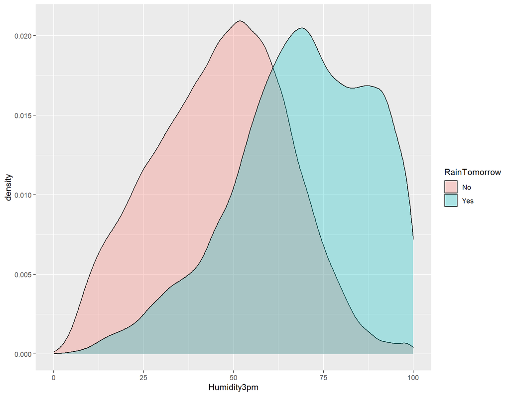

```r
aus %>%
  select(Humidity3pm, RainTomorrow) %>%
  drop_na() %>%
  ggplot(aes(Humidity3pm, fill = RainTomorrow)) +
  geom_density(alpha = 0.3)
```

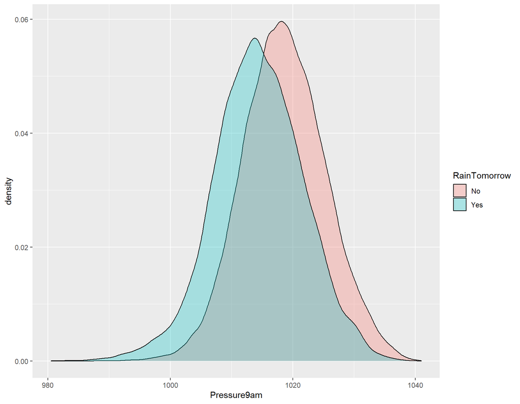

```r
### Pressure seems to have a moderate effect

aus %>%
  select(Pressure9am, RainTomorrow) %>%
  drop_na() %>%
  ggplot(aes(Pressure9am, fill = RainTomorrow)) +
  geom_density(alpha = 0.3)
```

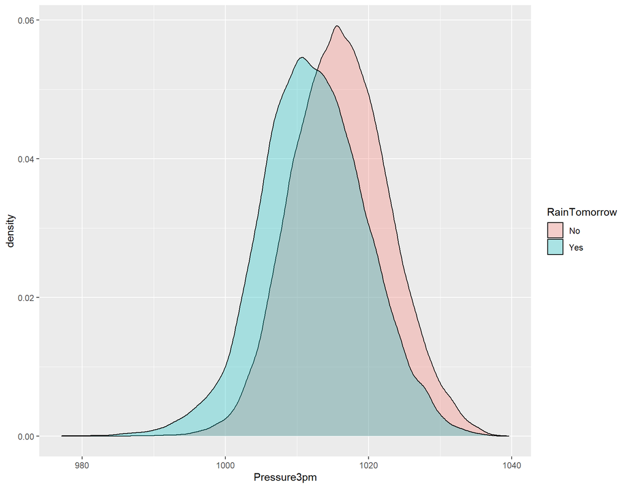

```r
aus %>%
  select(Pressure3pm, RainTomorrow) %>%
  drop_na() %>%
  ggplot(aes(Pressure3pm, fill = RainTomorrow)) +
  geom_density(alpha = 0.3)
```

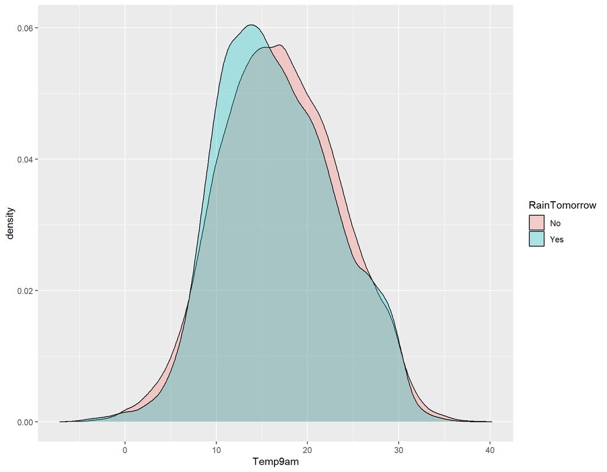

```r
### Temperature seems important

aus %>%
  select(Temp9am, RainTomorrow) %>%
  drop_na() %>%
  ggplot(aes(Temp9am, fill = RainTomorrow)) +
  geom_density(alpha = 0.3)
```

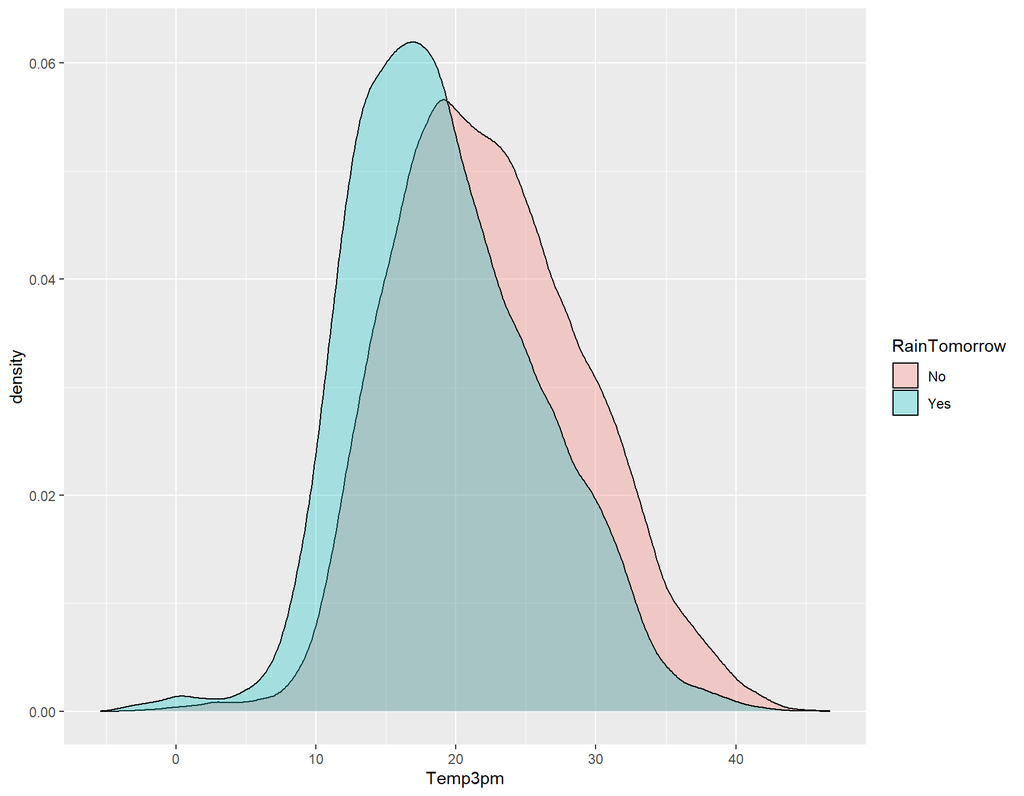

```r
aus %>%
  select(Temp3pm, RainTomorrow) %>%
  drop_na() %>%
  ggplot(aes(Temp3pm, fill = RainTomorrow)) +
  geom_density(alpha = 0.3)
```

```r
graphics.off()
```

# 3 Dataset for Modeling, After EDA

Here we select the variables that have some relation with the variable Rain Tomorrow. So we create a new dataset with reduced variable, this dataset will be used for building our Random Forest Model. The data had some missing data. We dropped these missing observations from the data. Also Sunshine and Evaporation variable has too many missing observations. So we will not use these two variables, otherwise we remove out almost half of our data.

```r
aus_df <- aus %>%
  select(Location,
         RainTomorrow,
         WindGustDir,
         WindDir9am,
         WindDir3pm,
         RainToday,
         WindGustSpeed,
         MinTemp,
         MaxTemp,
         Rainfall,
         Humidity9am,
         Humidity3pm,
         Pressure9am,
         Pressure3pm,
         Temp3pm
         ) %>%
  mutate(Month = factor(lubridate::month(aus$Date, label = TRUE), ordered = FALSE)) %>% ### Extracted only months from the Date Variable
  drop_na() %>%
  mutate_if(is.character, as.factor) %>%
            mutate(RainTomorrow = relevel(RainTomorrow, ref = "Yes"))
```

## 3.1 Summary of the Final Data

```r
glimpse(aus_df)
```

```
## Rows: 112,925
## Columns: 16
## $ Location      <fct> Albury, Albury, Albury, Albury, Albury, Albury, Albur...
## $ RainTomorrow  <fct> No, No, No, No, No, No, No, No, Yes, No, Yes, Yes, Ye...
## $ WindGustDir   <fct> W, WNW, WSW, NE, W, WNW, W, W, NNW, W, N, NNE, W, SW,...
## $ WindDir9am    <fct> W, NNW, W, SE, ENE, W, SW, SSE, SE, S, SSE, NE, NNW, ...
## $ WindDir3pm    <fct> WNW, WSW, WSW, E, NW, W, W, W, NW, SSE, ESE, ENE, NNW...
## $ RainToday     <fct> No, No, No, No, No, No, No, No, No, Yes, No, Yes, Yes...
## $ WindGustSpeed <dbl> 44, 44, 46, 24, 41, 56, 50, 35, 80, 28, 30, 31, 61, 4...
## $ MinTemp       <dbl> 13.4, 7.4, 12.9, 9.2, 17.5, 14.6, 14.3, 7.7, 9.7, 13....
## $ MaxTemp       <dbl> 22.9, 25.1, 25.7, 28.0, 32.3, 29.7, 25.0, 26.7, 31.9,...
## $ Rainfall      <dbl> 0.6, 0.0, 0.0, 0.0, 1.0, 0.2, 0.0, 0.0, 0.0, 1.4, 0.0...
## $ Humidity9am   <dbl> 71, 44, 38, 45, 82, 55, 49, 48, 42, 58, 48, 89, 76, 6...
## $ Humidity3pm   <dbl> 22, 25, 30, 16, 33, 23, 19, 19, 9, 27, 22, 91, 93, 43...
## $ Pressure9am   <dbl> 1007.7, 1010.6, 1007.6, 1017.6, 1010.8, 1009.2, 1009....
## $ Pressure3pm   <dbl> 1007.1, 1007.8, 1008.7, 1012.8, 1006.0, 1005.4, 1008....
## $ Temp3pm       <dbl> 21.8, 24.3, 23.2, 26.5, 29.7, 28.9, 24.6, 25.5, 30.2,...
## $ Month         <fct> Dec, Dec, Dec, Dec, Dec, Dec, Dec, Dec, Dec, Dec, Dec...
```

```r
### Check Level of Dependent Variable
levels(aus_df$RainTomorrow)
```

```
## [1] "Yes" "No"
```

Our model will take “Yes” as success level of RainTomorrow variable.

# 4 Model Fitting

## 4.1 Split Data in Training and Testing sets

We fit the model using the training data, and evaluate or model on the testing dataset.

```r
### We will use Logistic Regression and Random Forest for Modeling ###

set.seed(123)
aus_split <- initial_split(aus_df, strata = RainTomorrow)
aus_train <- training(aus_split)
aus_test <- testing(aus_split)
aus_split # Shows Training/Testing/Total Observations
```

```
## <Analysis/Assess/Total>
## <84695/28230/112925>
```

## 4.2 Create Cross Validation Datasets

We create Cross Validation data sets, we use these datasets for tuning our Random Forest Model’s Hyperparameters. We use the Training set for cross validation. We create 10-folds cross validation dataset.

```r
aus_cv <- vfold_cv(aus_train, strata = RainTomorrow)
aus_cv
```

```
## #  10-fold cross-validation using stratification
## # A tibble: 10 x 2
##    splits               id
##    <list>               <chr>
##  1 <split [76.2K/8.5K]> Fold01
##  2 <split [76.2K/8.5K]> Fold02
##  3 <split [76.2K/8.5K]> Fold03
##  4 <split [76.2K/8.5K]> Fold04
##  5 <split [76.2K/8.5K]> Fold05
##  6 <split [76.2K/8.5K]> Fold06
##  7 <split [76.2K/8.5K]> Fold07
##  8 <split [76.2K/8.5K]> Fold08
##  9 <split [76.2K/8.5K]> Fold09
## 10 <split [76.2K/8.5K]> Fold10
```

## 4.3 Model Specification

In this step we specify the models, the engine to fit the model, and some other specifications. We will fit a logistic regression too, just to compare our RF model.

```r
### Logistic Regression

glm_spec <- logistic_reg() %>%
  set_engine("glm")

glm_spec
```

```
## Logistic Regression Model Specification (classification)
##
## Computational engine: glm
```

```r
### Random Forest
rf_spec <- rand_forest(
  mtry = tune(), ### We tune this hyperparameter via Cross Validation
  trees = 500,   ### We grow 500 random trees, That's going to be used for prediction
  min_n = tune() ### We tune this hyperparameter via Cross Validation
) %>%
  set_mode("classification") %>%
  set_engine("ranger")

rf_spec
```

```
## Random Forest Model Specification (classification)
##
## Main Arguments:
##   mtry = tune()
##   trees = 500
##   min_n = tune()
##
## Computational engine: ranger
```

## 4.4 Workflow

Workflow allows to specify steps of model fitting. First we specify the formula, then we can add the model in the workflow. Workflow allows us to add model specification, recipe of feature engineering, model etc in a lego block type style. This is really useful for changing any part of the model very easily.

```r
### Workflow

aus_wf <- workflow() %>%
  add_formula(RainTomorrow ~ .)

aus_wf
```

```
## == Workflow ===========================================
## Preprocessor: Formula
## Model: None
##
## -- Preprocessor ---------------------------------------
## RainTomorrow ~ .
```

```r
### Parallel Processing

doParallel::registerDoParallel()
```

## 4.5 Fitting Logistic Regression

### 4.5.1 Fit logistic on the Cross Validated Dataset

```r
glm_rs <- aus_wf %>%
  add_model(glm_spec) %>%
  fit_resamples(
    resamples = aus_cv,
    control = control_resamples(save_pred = TRUE)
  )
```

### 4.5.2 Assess the performance of the logistic model

```r
glm_rs
```

```
## # Resampling results
## # 10-fold cross-validation using stratification
## # A tibble: 10 x 5
##    splits              id     .metrics        .notes         .predictions
##    <list>              <chr>  <list>          <list>         <list>
##  1 <split [76.2K/8.5K~ Fold01 <tibble [2 x 3~ <tibble [0 x ~ <tibble [8,470 x 5~
##  2 <split [76.2K/8.5K~ Fold02 <tibble [2 x 3~ <tibble [0 x ~ <tibble [8,470 x 5~
##  3 <split [76.2K/8.5K~ Fold03 <tibble [2 x 3~ <tibble [0 x ~ <tibble [8,470 x 5~
##  4 <split [76.2K/8.5K~ Fold04 <tibble [2 x 3~ <tibble [0 x ~ <tibble [8,470 x 5~
##  5 <split [76.2K/8.5K~ Fold05 <tibble [2 x 3~ <tibble [0 x ~ <tibble [8,470 x 5~
##  6 <split [76.2K/8.5K~ Fold06 <tibble [2 x 3~ <tibble [0 x ~ <tibble [8,469 x 5~
##  7 <split [76.2K/8.5K~ Fold07 <tibble [2 x 3~ <tibble [0 x ~ <tibble [8,469 x 5~
##  8 <split [76.2K/8.5K~ Fold08 <tibble [2 x 3~ <tibble [0 x ~ <tibble [8,469 x 5~
##  9 <split [76.2K/8.5K~ Fold09 <tibble [2 x 3~ <tibble [0 x ~ <tibble [8,469 x 5~
## 10 <split [76.2K/8.5K~ Fold10 <tibble [2 x 3~ <tibble [0 x ~ <tibble [8,469 x 5~
```

```r
collect_metrics(glm_rs)
```

```
## # A tibble: 2 x 5
##   .metric  .estimator  mean     n std_err
##   <chr>    <chr>      <dbl> <int>   <dbl>
## 1 accuracy binary     0.853    10 0.00118
## 2 roc_auc  binary     0.874    10 0.00123
```

### 4.5.3 Sensitivity & Specificity of Logistic Model

```r
glm_rs %>%
  collect_predictions() %>%
  sensitivity(RainTomorrow, .pred_class)
```

```
## # A tibble: 1 x 3
##   .metric .estimator .estimate
##   <chr>   <chr>          <dbl>
## 1 sens    binary         0.520
```

```r
glm_rs %>%
  collect_predictions() %>%
  specificity(RainTomorrow, .pred_class)
```

```
## # A tibble: 1 x 3
##   .metric .estimator .estimate
##   <chr>   <chr>          <dbl>
## 1 spec    binary         0.948
```

### 4.5.4 Confusion Matrix of Logistic Model

```r
glm_rs %>%
  conf_mat_resampled()
```

```
## # A tibble: 4 x 3
##   Prediction Truth  Freq
##   <fct>      <fct> <dbl>
## 1 Yes        Yes    976.
## 2 Yes        No     342.
## 3 No         Yes    900.
## 4 No         No    6251.
```

### 4.5.5 Fit the logistic model on Whole training data and Evaluate on Test Data

```r
aus_final <- aus_wf %>%
  add_model(glm_spec) %>%
  last_fit(aus_split)

aus_final
```

```
## # Resampling results
## # Monte Carlo cross-validation (0.75/0.25) with 1 resamples
## # A tibble: 1 x 6
##   splits         id          .metrics     .notes      .predictions     .workflow
##   <list>         <chr>       <list>       <list>      <list>           <list>
## 1 <split [84.7K~ train/test~ <tibble [2 ~ <tibble [0~ <tibble [28,230~ <workflo~
```

```r
aus_final %>% collect_metrics()
```

```
## # A tibble: 2 x 3
##   .metric  .estimator .estimate
##   <chr>    <chr>          <dbl>
## 1 accuracy binary         0.851
## 2 roc_auc  binary         0.874
```

```r
## Confusion matrix on the Test data

aus_final %>%
  collect_predictions() %>%
  conf_mat(RainTomorrow, .pred_class)
```

```
##           Truth
## Prediction   Yes    No
##        Yes  3221  1166
##        No   3033 20810
```

```r
aus_final$.workflow[[1]] %>%
  tidy(exponentiate = TRUE) %>%
  arrange(p.value) %>%
  filter(term != "(Intercept)", p.value < 0.05) %>%
  knitr::kable()
```

| term | estimate | std.error | statistic | p.value |
| --- | --- | --- | --- | --- |
| WindGustSpeed | 0.9535625 | 0.0009876 | -48.148050 | 0.0000000 |
| Humidity3pm | 0.9265660 | 0.0012420 | -61.409036 | 0.0000000 |
| Pressure3pm | 1.2640594 | 0.0073163 | 32.028070 | 0.0000000 |
| Pressure9am | 0.8412601 | 0.0073046 | -23.663736 | 0.0000000 |
| LocationWollongong | 7.0066112 | 0.0963381 | 20.208562 | 0.0000000 |
| LocationNorahHead | 6.1855316 | 0.0961981 | 18.942301 | 0.0000000 |
| LocationTownsville | 7.0236202 | 0.1068185 | 18.248513 | 0.0000000 |
| LocationDarwin | 5.7341085 | 0.1033530 | 16.897745 | 0.0000000 |
| LocationNorfolkIsland | 4.7411831 | 0.0926892 | 16.790369 | 0.0000000 |
| LocationGoldCoast | 5.0003229 | 0.0981166 | 16.403977 | 0.0000000 |
| RainTodayYes | 0.6441022 | 0.0286172 | -15.371814 | 0.0000000 |
| LocationBallarat | 3.5735074 | 0.1010975 | 12.597219 | 0.0000000 |
| LocationCairns | 3.5362171 | 0.1012029 | 12.480443 | 0.0000000 |
| LocationSale | 3.1321139 | 0.0996143 | 11.461283 | 0.0000000 |
| LocationSydneyAirport | 2.8984182 | 0.0952568 | 11.171542 | 0.0000000 |
| MinTemp | 0.9485147 | 0.0048122 | -10.984231 | 0.0000000 |
| LocationCoffsHarbour | 2.8776826 | 0.0970052 | 10.896175 | 0.0000000 |
| LocationHobart | 2.7877858 | 0.0966999 | 10.602360 | 0.0000000 |
| MonthApr | 0.5749861 | 0.0558724 | -9.904883 | 0.0000000 |
| LocationMelbourneAirport | 2.6268596 | 0.0980006 | 9.854933 | 0.0000000 |
| LocationKatherine | 5.6573074 | 0.1828811 | 9.475817 | 0.0000000 |
| MonthMay | 0.5644623 | 0.0608760 | -9.394201 | 0.0000000 |
| MonthAug | 0.5344321 | 0.0669010 | -9.365346 | 0.0000000 |
| LocationWalpole | 2.3291937 | 0.0917895 | 9.211538 | 0.0000000 |
| LocationLaunceston | 2.9593517 | 0.1202747 | 9.020772 | 0.0000000 |
| LocationWoomera | 3.0095624 | 0.1314665 | 8.380800 | 0.0000000 |
| LocationMelbourne | 2.3239307 | 0.1013932 | 8.316732 | 0.0000000 |
| LocationNhil | 2.9143598 | 0.1299656 | 8.230258 | 0.0000000 |
| LocationWilliamtown | 2.2707106 | 0.1012217 | 8.101950 | 0.0000000 |
| LocationPortland | 2.0909112 | 0.0916571 | 8.047388 | 0.0000000 |

[output cut: 52 more lines]

## 4.6 Fitting Random Forest Model via tuning HyperParamaters *mtry* & *min_n*

*mtry* is number of variables to randomly consider for splitting at each node. *mtry* number of variables are selected at random, then split the node according to the variable that produce highest PURITY. *min_n* is the number observation in a node to be considered to be split further. *min_n* is used to control overfitting.

Number of trees to build in a random forest is also a hyperparameter. But we choose it to be 500 this time. Our model takes an observation, then predicts the outcome of this observation on 500 trees, then takes the highest appearing classification among these 500 trees. That’s the idea behind RF model.

If we fit a very complex tree, it will have many terminal nodes, and it will have high variance on predictions for a new dataset.

All these hyperparameters need to be decided by experimenting on the dataset, as there is no particular rule for choosing their values.

Both *mtry* and *min_n* will be choosen via a cross validation method. First we take a combination of *mtry* and *min_n*, then fit a random forest model with each combination. And for each such random forest we evaluate the performance of each tree in our cross validation datasets, and record the performance via accuracy and AUC.

Then we can check which combination of *mtry* and *min_n* results in highest accuracy and AUC. Then we fit a model again on our whole Training dataset using this combination. and evaluate on the test dataset to check for overfitting.

Tidymodels *tune_grid* allows us to tune models via cross validation.

```r
## Create a workflow for tuning random forest
## Add the random forest model to the workflow
## Then start tuning ===>>>

tune_wf <- aus_wf %>%
  add_model(rf_spec)

tune_wf
```

```
## == Workflow ===========================================
## Preprocessor: Formula
## Model: rand_forest()
##
## -- Preprocessor ---------------------------------------
## RainTomorrow ~ .
##
## -- Model ----------------------------------------------
## Random Forest Model Specification (classification)
##
## Main Arguments:
##   mtry = tune()
##   trees = 500
##   min_n = tune()
##
## Computational engine: ranger
```

### 4.6.1 Tuning RF via Cross Validation and Save Results

We take 25 combinations of *mtry* and *min_n* for tuning. The model will automatically decide on the values of the combinations. Also number of trees in each random forest model is set to 500 in *rf_spec*. These numbers could be increased, but for this time, it is okay to use lower numbers, as it takes long time to tune Random Forest.

```r
### Takes 300 mins

rf_rs_tune <- tune_grid(
  object = tune_wf,
  resamples = aus_cv,
  grid = 25,
  control = control_resamples(save_pred = TRUE)
)

### Results of Tuning
rf_rs_tune
```

```
## # Tuning results
## # 10-fold cross-validation using stratification
## # A tibble: 10 x 5
##    splits             id     .metrics        .notes         .predictions
##    <list>             <chr>  <list>          <list>         <list>
##  1 <split [76.2K/8.5~ Fold01 <tibble [50 x ~ <tibble [0 x ~ <tibble [211,750 x ~
##  2 <split [76.2K/8.5~ Fold02 <tibble [50 x ~ <tibble [0 x ~ <tibble [211,750 x ~
##  3 <split [76.2K/8.5~ Fold03 <tibble [50 x ~ <tibble [0 x ~ <tibble [211,750 x ~
##  4 <split [76.2K/8.5~ Fold04 <tibble [50 x ~ <tibble [0 x ~ <tibble [211,750 x ~
##  5 <split [76.2K/8.5~ Fold05 <tibble [50 x ~ <tibble [0 x ~ <tibble [211,750 x ~
##  6 <split [76.2K/8.5~ Fold06 <tibble [50 x ~ <tibble [0 x ~ <tibble [211,725 x ~
##  7 <split [76.2K/8.5~ Fold07 <tibble [50 x ~ <tibble [0 x ~ <tibble [211,725 x ~
##  8 <split [76.2K/8.5~ Fold08 <tibble [50 x ~ <tibble [0 x ~ <tibble [211,725 x ~
##  9 <split [76.2K/8.5~ Fold09 <tibble [50 x ~ <tibble [0 x ~ <tibble [211,725 x ~
## 10 <split [76.2K/8.5~ Fold10 <tibble [50 x ~ <tibble [0 x ~ <tibble [211,725 x ~
```

```r
### Check Accuracy and AUC after tuning
rf_rs_tune %>%
  collect_metrics()
```

```
## # A tibble: 50 x 8
##     mtry min_n .metric  .estimator  mean     n  std_err .config
##    <int> <int> <chr>    <chr>      <dbl> <int>    <dbl> <chr>
##  1     2    16 accuracy binary     0.856    10 0.000951 Model01
##  2     2    16 roc_auc  binary     0.888    10 0.00115  Model01
##  3     7     6 accuracy binary     0.858    10 0.000868 Model02
##  4     7     6 roc_auc  binary     0.888    10 0.00111  Model02
##  5    10    34 accuracy binary     0.857    10 0.000744 Model03
##  6    10    34 roc_auc  binary     0.885    10 0.00111  Model03
##  7     9     8 accuracy binary     0.858    10 0.000773 Model04
##  8     9     8 roc_auc  binary     0.887    10 0.000996 Model04
##  9     6    40 accuracy binary     0.856    10 0.000848 Model05
## 10     6    40 roc_auc  binary     0.887    10 0.00106  Model05
## # ... with 40 more rows
```

```r
# Remove previous Graphs from memory
graphics.off()
```

### 4.6.2 Observe mtry & min_n combinations via plot

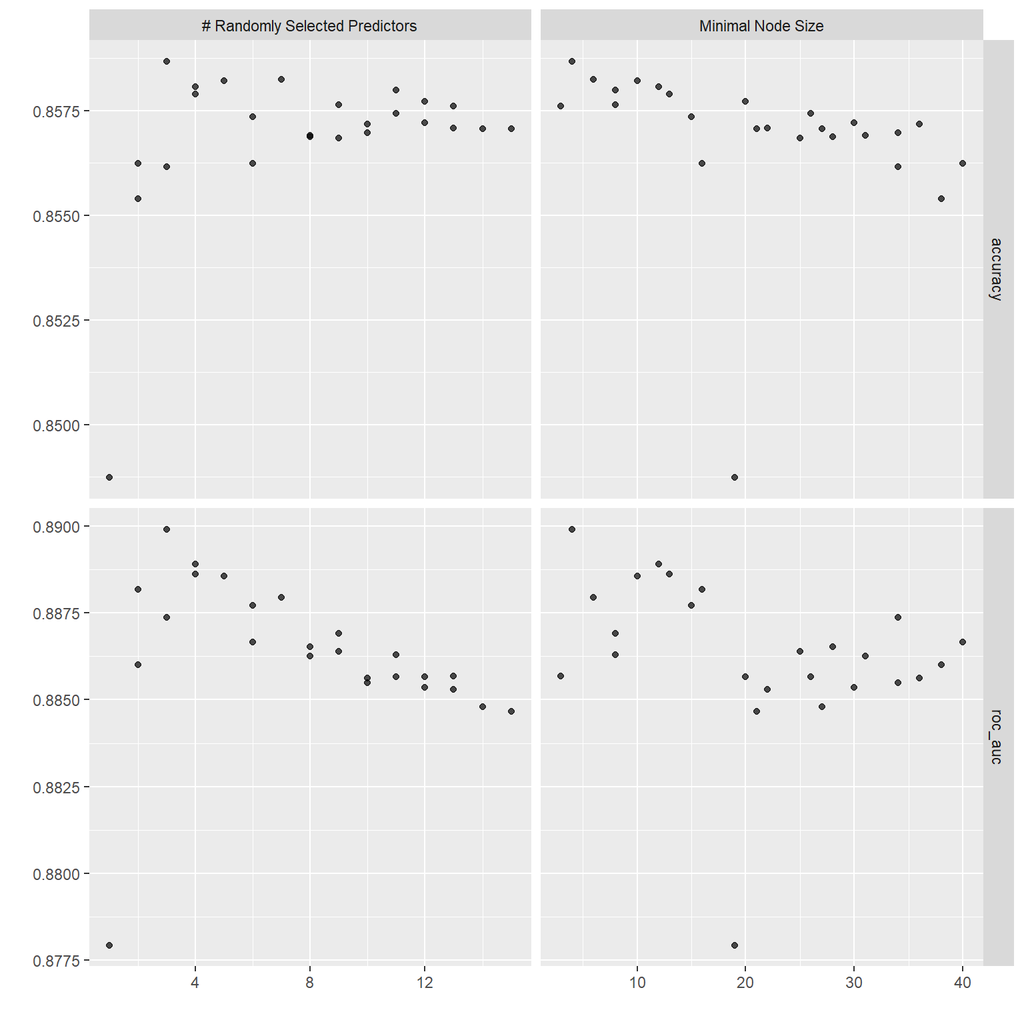

```r
autoplot(rf_rs_tune)
```

The autoplot shows combination of *mtry* and *min_n*, and shows for which values the Accuracy and AUC have highest values. This helps us to choose the BEST hyperparameter values. We can either select that gives best accuracy or the on that results in best AUC. This depends on the problem and what we are predicting and classifying.

### 4.6.3 Check Sensitivity and Specifity by Each Fold in a ROC curve

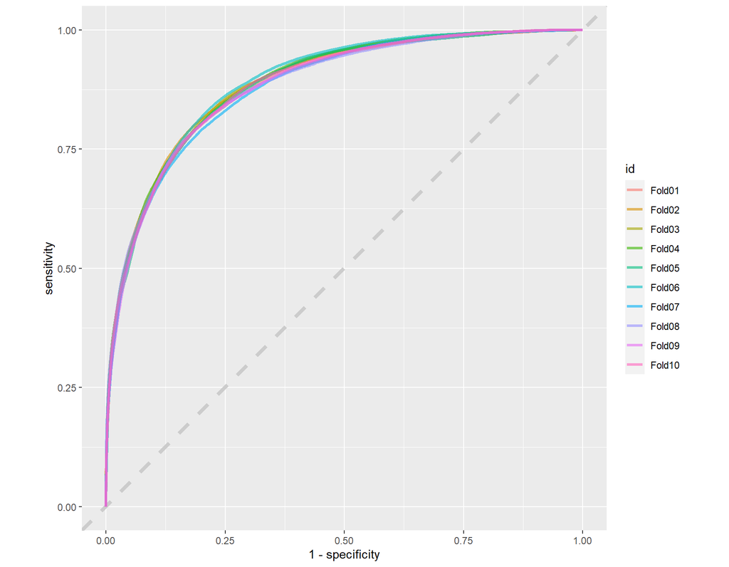

```r
rf_rs_tune %>%
  collect_predictions() %>%
  group_by(id) %>%
  roc_curve(RainTomorrow, .pred_Yes) %>%
  ggplot(aes(1 - specificity, sensitivity, color = id)) +
  geom_abline(lty = 2, color = "gray80", size = 1.5) +
  geom_path(show.legend = TRUE, alpha = 0.6, size = 1.2) +
  coord_equal()
```

ROC curves indicate that each Fold performs similar with True Positive and False Positive classification, indicating the robustness of predictions via Random Forest.

### 4.6.4 Select best model according to Accuracy and AUC

```r
best_acu <- select_best(rf_rs_tune, "accuracy")
best_acu
```

```
## # A tibble: 1 x 3
##    mtry min_n .config
##   <int> <int> <chr>
## 1     3     4 Model12
```

```r
### Also check which model has the highest AUC

best_auc <- select_best(rf_rs_tune, "roc_auc")
best_auc
```

```
## # A tibble: 1 x 3
##    mtry min_n .config
##   <int> <int> <chr>
## 1     3     4 Model12
```

### 4.6.5 Finalize Model After HyperParameter Tuning and according to accuracy

```r
rf_final <- finalize_model(
  rf_spec,
  best_acu
)

rf_final #### This is the Best Model from our CV
```

```
## Random Forest Model Specification (classification)
##
## Main Arguments:
##   mtry = 3
##   trees = 500
##   min_n = 4
##
## Computational engine: ranger
```

## 4.7 Test Data and model evaluation

### 4.7.1 Fit the final selected TUNED model in full Training Data & Predict on Test data & Check for overfitting

The *last_fit* fits the model on Training and evaluates on Test dataset of the *split*.

```r
final_res <- aus_wf %>%
  add_model(spec = rf_final) %>%
  last_fit(aus_split)
```

### 4.7.2 Check Accuracy & OVerfitting on Test Data

```r
final_res %>%
  collect_metrics()
```

```
## # A tibble: 2 x 3
##   .metric  .estimator .estimate
##   <chr>    <chr>          <dbl>
## 1 accuracy binary         0.859
## 2 roc_auc  binary         0.893
```

About the same as in CV. So we didnt overfit our data on Training set.

### 4.7.3 Confusion Matrix on Test Data

```r
final_res %>%
  collect_predictions() %>%
  conf_mat(RainTomorrow, .pred_class)
```

```
##           Truth
## Prediction   Yes    No
##        Yes  3275   995
##        No   2979 20981
```

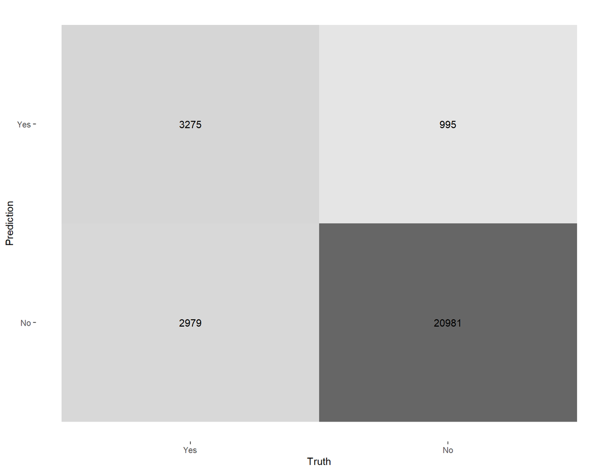

```r
final_res %>%
  collect_predictions() %>%
  conf_mat(RainTomorrow, .pred_class) %>%
  autoplot(type = "heatmap")
```

### 4.7.4 Sensitivity & Specificity

```r
final_res %>%
  collect_predictions() %>%
  sensitivity(RainTomorrow, .pred_class)
```

```
## # A tibble: 1 x 3
##   .metric .estimator .estimate
##   <chr>   <chr>          <dbl>
## 1 sens    binary         0.524
```

```r
final_res %>%
  collect_predictions() %>%
  specificity(RainTomorrow, .pred_class)
```

```
## # A tibble: 1 x 3
##   .metric .estimator .estimate
##   <chr>   <chr>          <dbl>
## 1 spec    binary         0.955
```

### 4.7.5 Variable Importance

Fits the model multiple times, by permutation of variables. If the predictions change significantly after permutation of a variable, that variable has high impact on outcome.

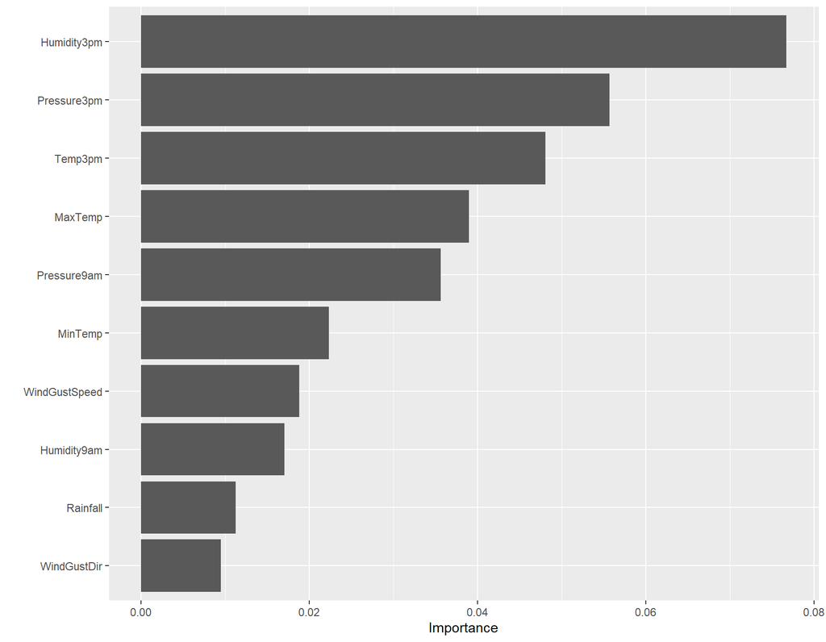

```r
library(vip)

rf_final %>%
  set_engine("ranger", importance = "permutation") %>%
  fit(RainTomorrow ~ . ,
      data = aus_df
  ) %>%
  vip(geom = "col")
```

# 5 Comment on the Model

## 5.1 Findings

- The model works good on predicting Not having Rain Tomorrow.
- But Predicting having Rain tomorrow in only 50-50 chance with this model.
- Overall The Random Forest Model Performs Slightly Better than Logistic Model.
- Humidity, Temperature, Pressure seems to be the most important variable in predicting tomorrows Rain.
- Locations seem to be significant in the logistic regression, but not in Random Forest Model.

## 5.2 Further Improvement

- Impute Missing Values
- Impute Sunshine and Evaporation and use in the model building, alothough it may not be realistic.
- Try out Downsampling, as the predicted class is imbalanced (unequal sample size)
- Try different model, like XGboost, KNN.

# 6 Save the model and results for further use and deployment

```r
save.image("Random_Forest_RDS.RData")
```

So That’s it for fitting models in tidymodels package in R.